# Predict Sale Price of Houses in Ames, Iowa

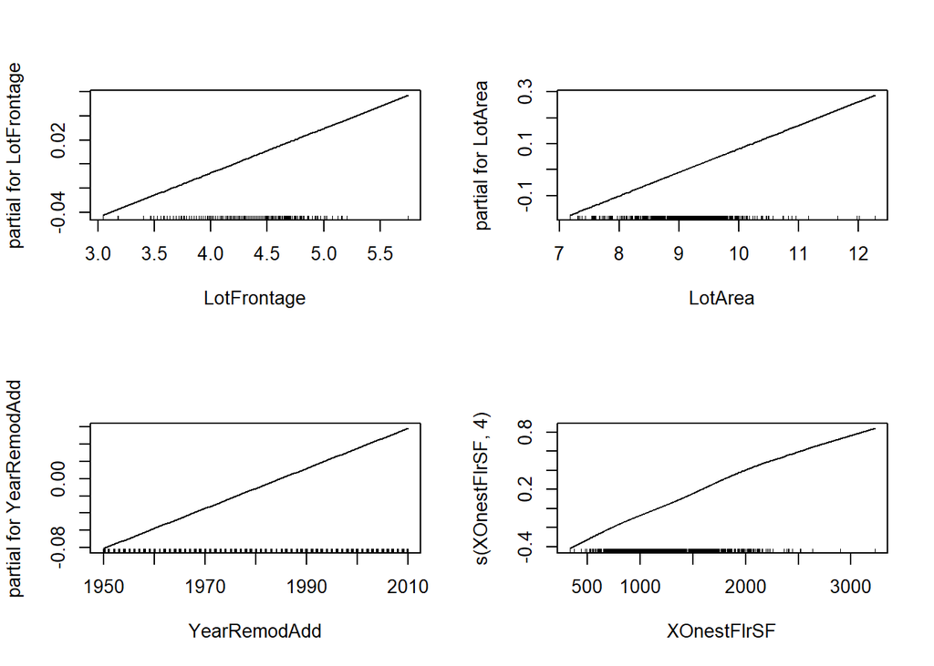

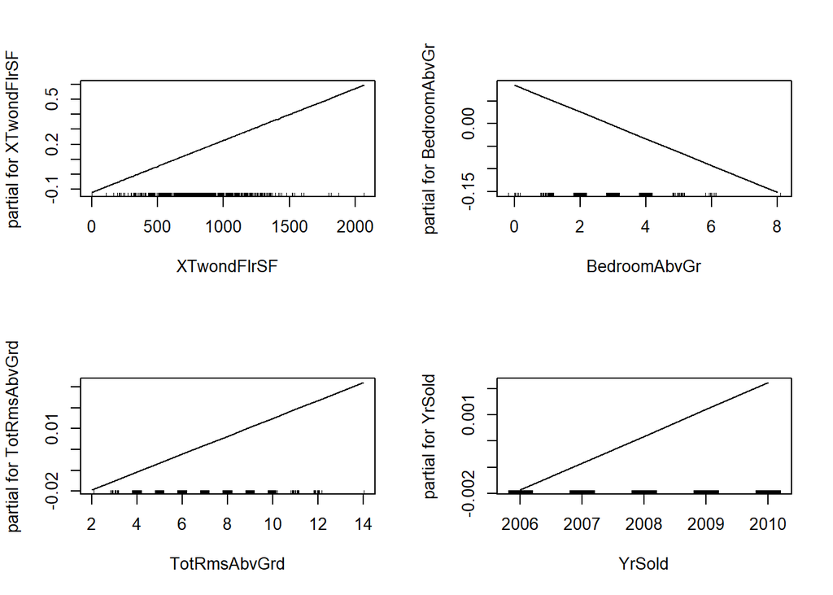

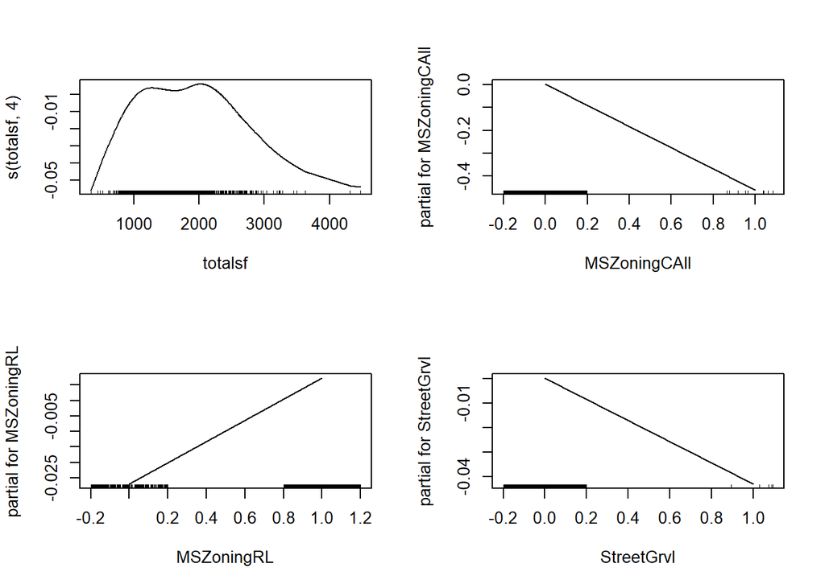

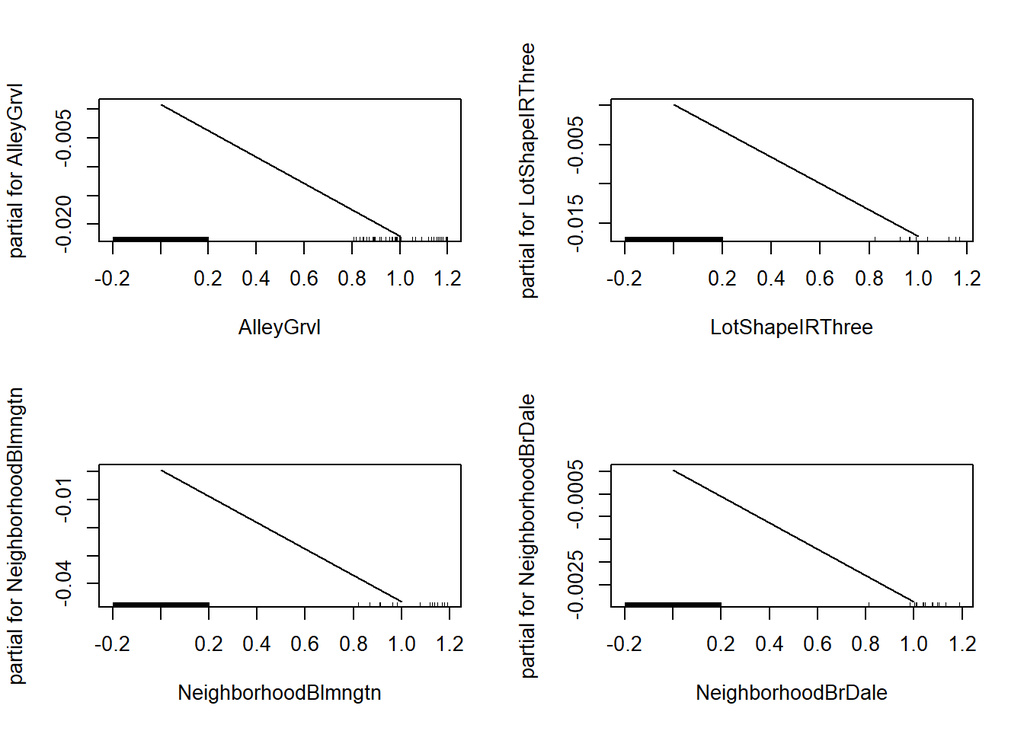

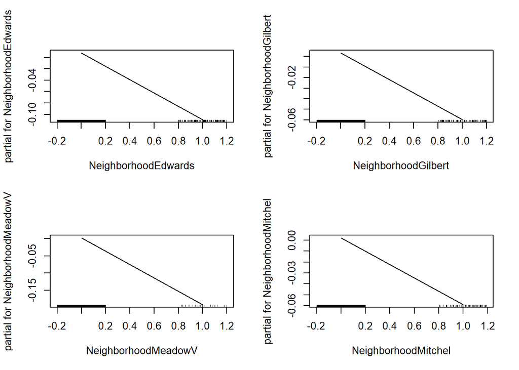

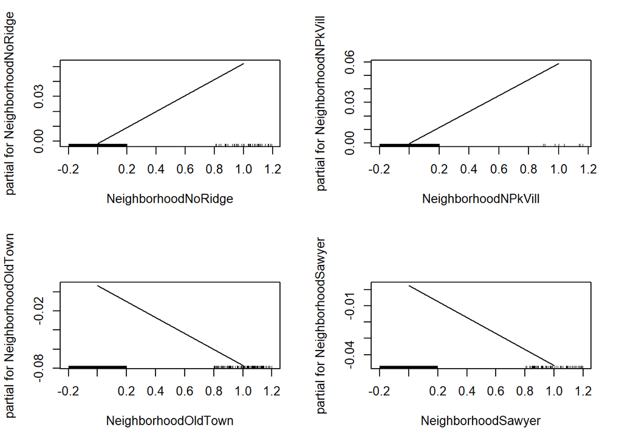

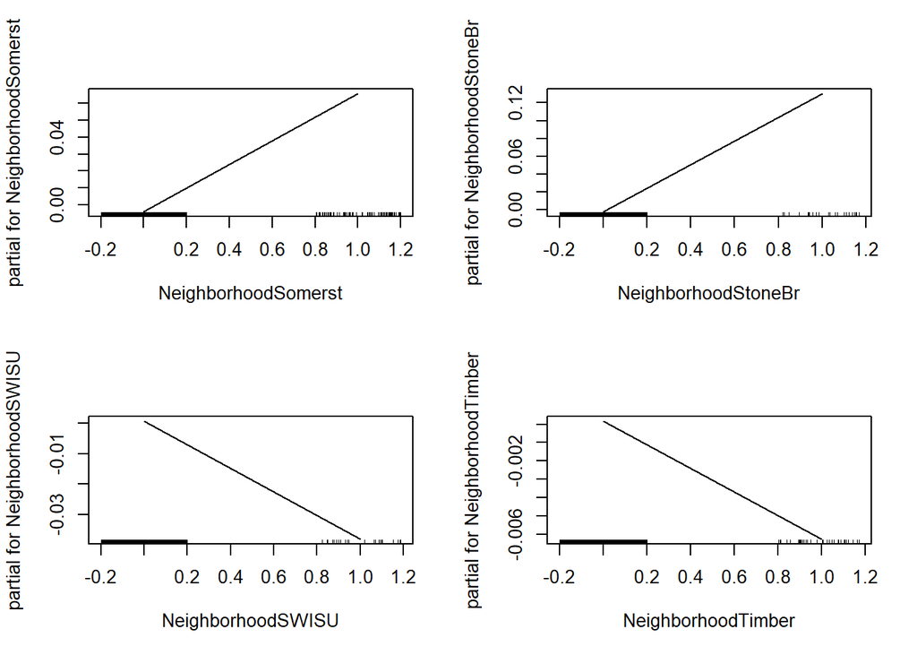

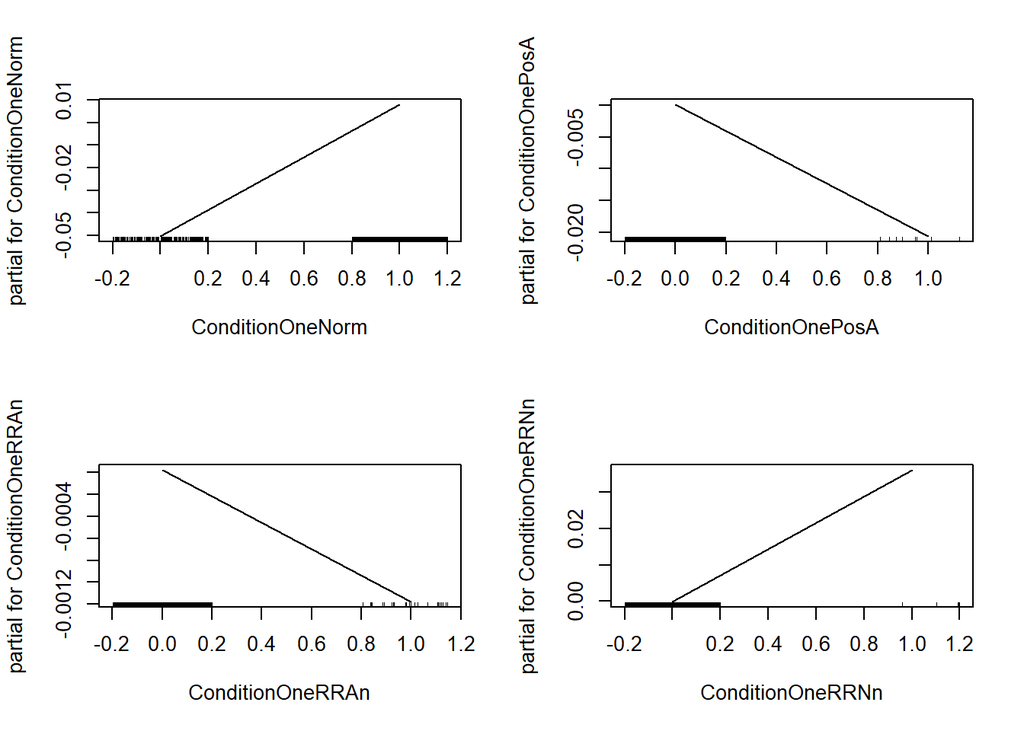

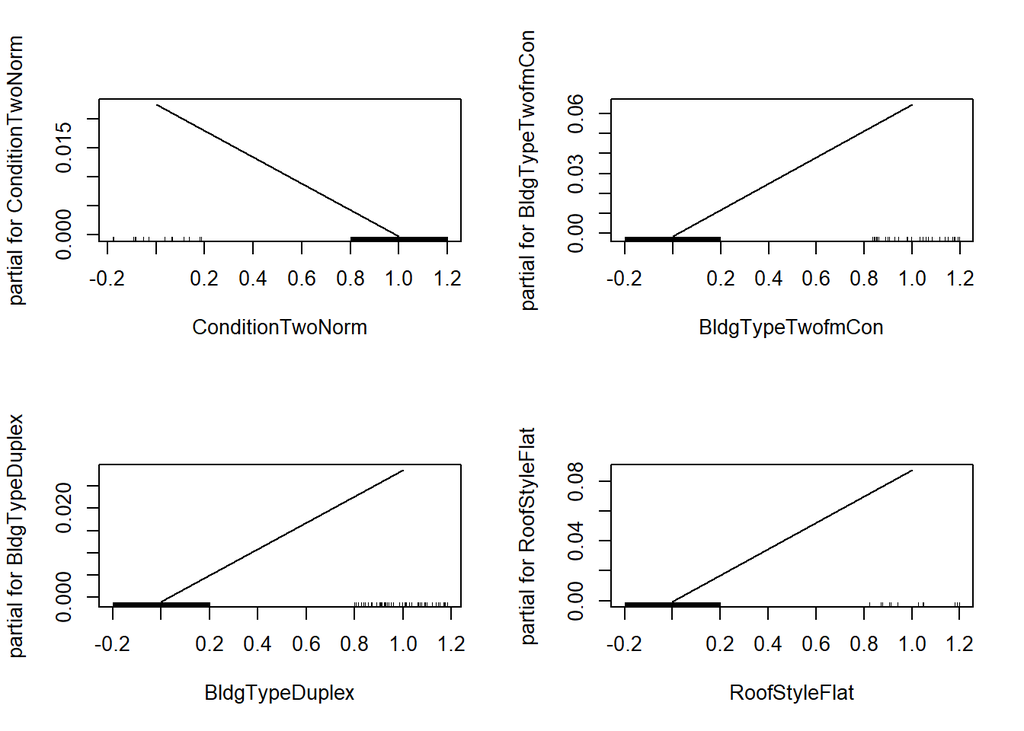

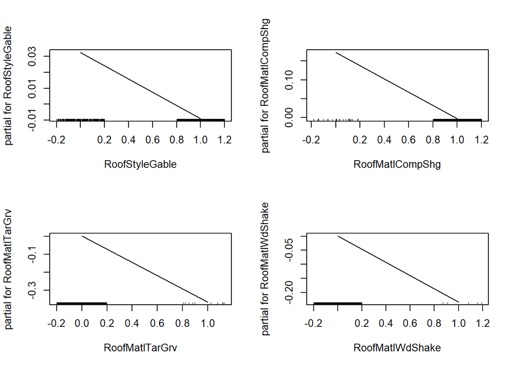

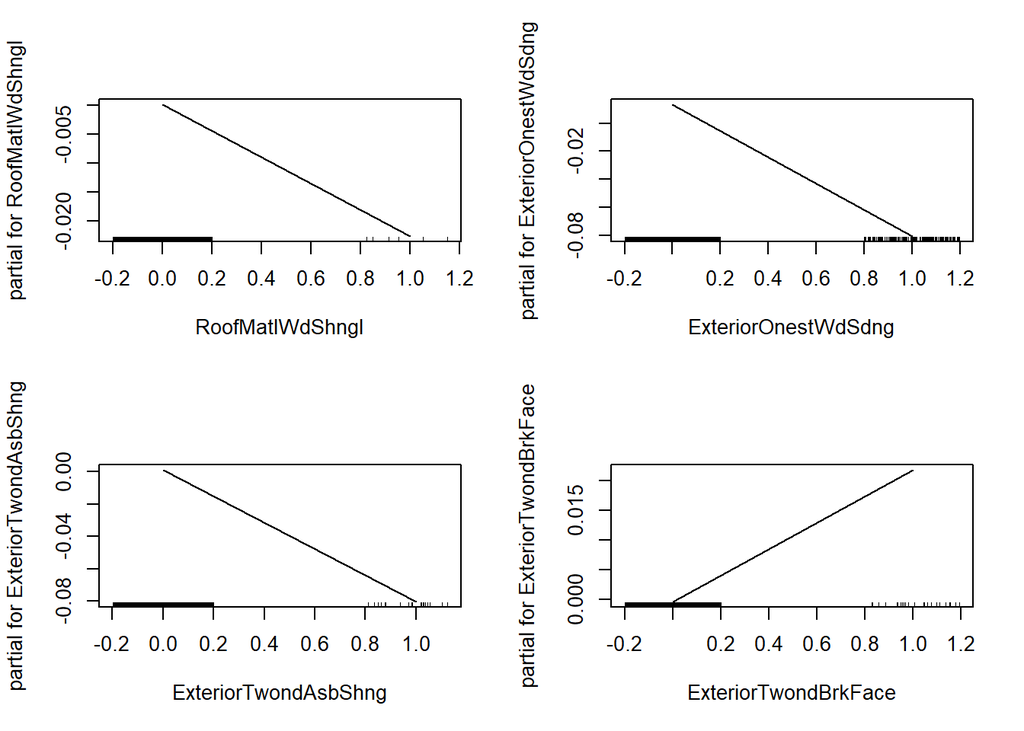

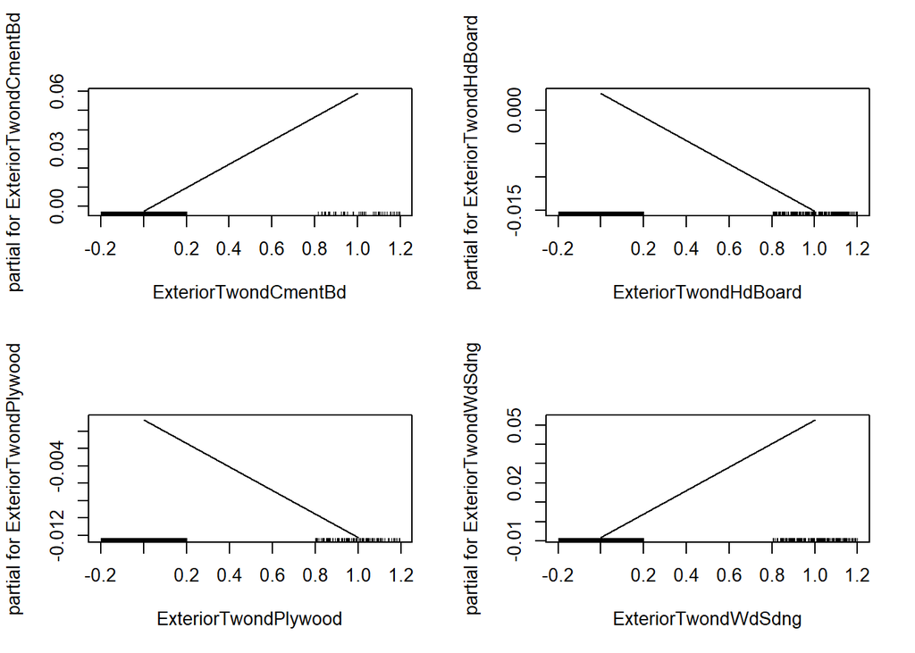

[13 more figures not shown]

```r
par(mfrow = c(2, 2))
plot(gam.model)
```

Though these graphs are compressed to save space, some meaningful relationships can still be observed.

For example, you can clearly see the nonlinear relationship in total square feet. And, we can also interpret the partials for the qualitative predictors. For example, houses in the Gilbert neighborhood is associated with a lower partial. And, having central air is associated with a high partial than not having central air.

## 12.5 Predictions

```r
gam.predictions <- predict(gam.model, newdata = test.final)
```

# 13 Before Submitting To Kaggle…

Before submitting to Kaggle, I thought the best method would be boosting, because it has the lowest cross validation error. However, this CV error is suspiciously low. Though I used the same method to compute estimated RMSE, it is possible I made a computational error.

```r
test_error = c(cv.rmse.linear, cv.rmse.knn, cv.rmse.bestsubset, cv.rmse.lasso,
    cv.rmse.ridge, cv.rmse.regression.tree, cv.rmse.random.forest, cv.rmse.boost,
    cv.rmse.bagging, cv.gam.4)

test_error
```

```
##  [1] 0.117987596 0.196952236 0.279464886 0.109156892 0.105813931 0.213339671
##  [7] 0.132723861 0.008769055 0.141490872 0.142295715
```

# 14 Kaggle

Create data frames to export the predictions for each method to a .csv file. Then, submit these predictions to Kaggle.

```r
knn.pred.final <- data.frame(SalePrice = knn.pred)
rownames(knn.pred.final) = seq(1461, 2919)
write.csv(knn.pred.final, "knnPredictionsFinal.csv")

lm.pred.final <- data.frame(SalePrice = lm.pred)
rownames(lm.pred.final) = seq(1461, 2919)
write.csv(lm.pred.final, "lmPredictionsFinal.csv")

lasso.pred.final <- data.frame(SalePrice = lasso.pred)
rownames(lasso.pred.final) = seq(1461, 2919)
write.csv(lasso.pred.final, "lassoPredictionsFinal.csv")

ridge.pred.final <- data.frame(SalePrice = ridge.pred)
rownames(ridge.pred.final) = seq(1461, 2919)
write.csv(ridge.pred.final, "ridgePredictionsFinal.csv")

bestsubset.pred.final <- data.frame(SalePrice = pred.best.subset)
rownames(bestsubset.pred.final) = seq(1461, 2919)
write.csv(bestsubset.pred.final, "bestsubsetPredictionsFinal.csv")

gam.pred.final <- data.frame(SalePrice = exp(gam.predictions))
rownames(gam.pred.final) = seq(1461, 2919)
write.csv(gam.pred.final, "gamPredictionsFinal.csv")


boost.pred.final <- data.frame(SalePrice = exp(boost.pred))
rownames(boost.pred.final) = seq(1461, 2919)
write.csv(boost.pred.final, "boostPredictionsFinal.csv")

bagging.pred.final <- data.frame(SalePrice = exp(bag.predictions))
rownames(bagging.pred.final) = seq(1461, 2919)
write.csv(bagging.pred.final, "baggingPredictionsFinal.csv")

randomforest.pred.final <- data.frame(SalePrice = exp(random.forest.pred))
rownames(randomforest.pred.final) = seq(1461, 2919)
write.csv(randomforest.pred.final, "randomForestPredictionsFinal.csv")

regressionTree.pred.final <- data.frame(SalePrice = regression.tree.predictions)
rownames(regressionTree.pred.final) = seq(1461, 2919)
write.csv(regressionTree.pred.final, "regressionTreePredictionsFinal.csv")
```

Here are my errors from Kaggle:

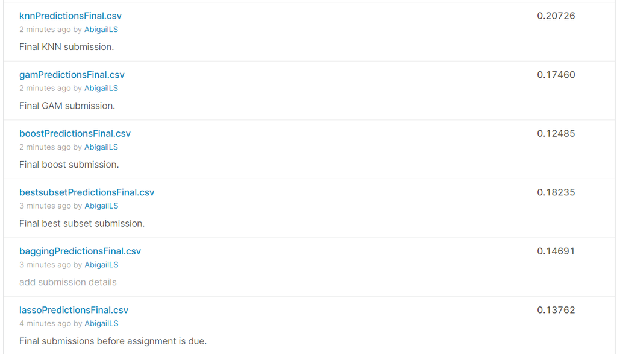

```r
knitr::include_graphics("FinalKaggle1.PNG")
```

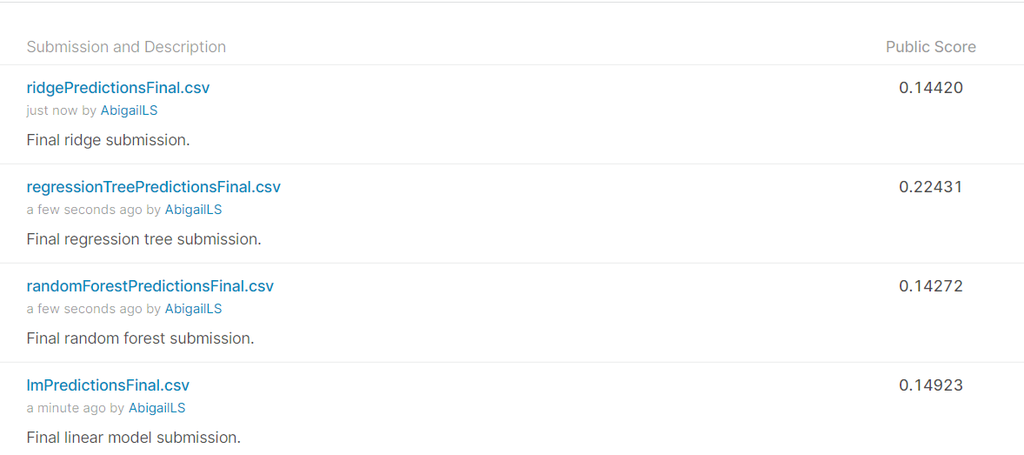

```r
knitr::include_graphics("FinalKaggle2.PNG")
```

This puts me at 1197 out of 5759 submissions.

# 15 Discussion

The method that performed the best was the boosting model. It makes sense that boosting performed better than the regression tree, because boosting is an approach to improve prediction results from a decision tree. And, boosting is a “slow” learner, so it’s able to avoid overfitting the data, which may have been an issue that the Random Forest method encountered.

The method that performed the worst is the regression tree. I suspect this is because regression trees can be unstable, so any small change in the data would have changed the tree and led to different predictions. And bagging, boosting, and random forest methods grow a “forest” of trees rather than just one tree, so it makes sense that this single regression tree performed worse than these methods. Not only that, but it is difficult to get accurate predictions for a continuous variable using a regression tree, because the possible SalePrice values took only 9 or 10 different values, while there is a wide range of continuous values that the sale price actually took.

In addition to the regression tree, KNN performed poorly. This is likely due to the dimensionality of the data. It is hard finding “nearest neighbors” when you have to match up 250 attributes.

# 16 Summary

In summary, I applied a range of machine learning methods to predict the sale price of houses in Ames, Iowa. After cleaning the data, I applied both linear and tree based methods to the data. Ultimately, the most accurate model was the boosting model, while regression trees and KNN performed poorly.

Here is a comparison of my estimated test errors with the true errors from Kaggle. I also calculated the prediction accuracy for each method:

```r
temp <- data.frame(method = c("Linear Regression", "KNN", "Subset Selection",
    "Lasso", "Ridge", "Regression Tree", "Random Forest", "Boosting", "Bagging",
    "GAM"), test_error = c(cv.rmse.linear, cv.rmse.knn, cv.rmse.bestsubset,
    cv.rmse.lasso, cv.rmse.ridge, cv.rmse.regression.tree, cv.rmse.random.forest,
    cv.rmse.boost, cv.rmse.bagging, cv.gam.4), true_error = c(0.14923,
    0.20726, 0.18235, 0.13762, 0.1442, 0.22431, 0.14272, 0.12485, 0.14691,
    0.1746), prediction_accuracy = 0.12/c(0.14923, 0.20726, 0.18235, 0.13762,
    0.1442, 0.22431, 0.14272, 0.12485, 0.14691, 0.1746) * 10)


kable(temp, col.names = c("Method", "CV Error", "Kaggle True Error", "Prediction Accuracy Score"))
```

| Method | CV Error | Kaggle True Error | Prediction Accuracy Score |
| --- | --- | --- | --- |
| Linear Regression | 0.1179876 | 0.14923 | 8.041279 |
| KNN | 0.1969522 | 0.20726 | 5.789829 |
| Subset Selection | 0.2794649 | 0.18235 | 6.580751 |
| Lasso | 0.1091569 | 0.13762 | 8.719663 |
| Ridge | 0.1058139 | 0.14420 | 8.321775 |
| Regression Tree | 0.2133397 | 0.22431 | 5.349739 |
| Random Forest | 0.1327239 | 0.14272 | 8.408072 |
| Boosting | 0.0087691 | 0.12485 | 9.611534 |
| Bagging | 0.1414909 | 0.14691 | 8.168266 |
| GAM | 0.1422957 | 0.17460 | 6.872852 |

Future directions of this project could be devoting more time on the tuning parameters for the boosting, bagging, and random forest methods. I was limited in doing this because of the sheer amount of time that cross-fold validation takes when building models with thousands of trees. However, I think my model can be further improved if I can tune the number of trees, the tuning parameter, and the number of predictors to try more precisely. While I attempted to tune the number of trees, I did not see an obvious local minimum in error. If I expand to include more trees, I suspect I will reach this local minimum.

Further, I am confused why the linear model performed better than the best subset selection model. This is clearly opposite of what is expected. Perhaps I removed a significant predictor of sale price; this, too, should be investigated further.

# 17 Conclusion

In conclusion, I successfully created multiple models to predict sale price. While not all were accurate predictors of sale price, some models were able to accurately predict sale price and yielded a low error rate.

# 18 Further Questions

Further questions raised by the study, that can be investigated in the future, include:

1. Are the important predictors of sale price in Ames, Iowa also important predictors in other cities? And, do we see a difference in important predictors when we compare urban and suburban areas to rural areas?
2. How has the housing market crash of 2008 influenced house sale prices? Will taking into account financial factors, such as unemployment or GDP, as predictors lead to better predictions?
3. Can the results of this study be applied to different years, once inflation is taken into account?